# City-Level Comparison Database

Fred Ramos

## Building a database on the coevolution of amenities and collectives

#### (Preliminary version for discussion)

This research focus on a “Comparative Macroscopic Perspective” and is part of a broader research project named “Between collectivization and enclosure: examining the uneven provision of clean water, waste disposal and public space in rapidly growing cities”, a VIDI project led by Prof. Justus Uitermark. The analysis requires the incorporation of city-level datasets containing contextual variables of configurations of collectivities and amenities as well as pathways between different configurations. This data gathering, and data analysis effort is oriented towards the question: **why residents of rapidly growing cities succeed or fail to secure amenities required for their health, dignity, and comfort?** The three amenities central to this project are: water, waste disposal and Public spaces (e.g. parks, sport fields, and squares).

The possibility to build a city-level dataset containing information about the amenities of interest is crutial for the achievement of satisfactory results. Four main aspects were considered when analyzing potential data sources: a large and representative sample of cities; the level of geographical disaggregation as city-level data is mandatory; the existence of comparable variables regarding amenities of interest and; the possibility to identify patterns of rapidly growing cities as this is the main driver.

The access to city-level statistics about amenities varies among countries. In general, information about amenities are derived from administrative cadasters maintained by local authorities. However, in most cases these administrative cadasters are not planned to give easy access and are kept under governmental information systems not publicly available. Additionally, differences in terms of administrative procedures and data registration may hinder the comparability among different cadastral systems. Nevertheless, maybe the most critical point of using administrative register to access data on amenities for rapidly growing cities is that, in many cases, these developments occurs under certain levels of informality where the official registers fails to capture the local dynamics of urban consolidation since the access of these amenities are guaranteed through “informal” channels as well.

Alternatively, many researches use household survey or censuses data to retrieve the information about access to amenities such as water and waste disposal. The obvious advantage is that the unit of observation is the household, making no difference if this household is in an informal or formal settlement. The censuses data bring, by definition, information about the universe of the population of a country and, in general, allow disaggregation by different geographical levels from regional aggregation to very local base as census tracks or blocks. However, sometimes is not possible to access highly disaggregated data. Results of household surveys based on samples give less flexibility in disaggregation depending directly on the size of the sample and how they are spatially distributed.

In comparative studies, the difficulties arise when the questionnaires are not directly comparable in terms of the definition of questions. It is necessary to harmonize the variables to make some comparison suitable. Some research institutes and development agencies have been working in gathering and organizing censuses and administrative data from different countries in order to facilitate comparative researches. Among them, the Institute for Social Research and Data Innovation at the University of Minnesota is responsible for the IPUMS Center for Data Integration which can be considered the leading provider of census and survey data from around the world. In general, these datasets are presented in different geographical aggregation levels having national coverages. This aspect imposes some difficulties when the subnational level is the interest of analysis. This is specifically the case of city-level analysis. Besides the necessity to access to desegregated information, is not unusual to observe a mismatch between the extension of the urbanized area of the city and the administrative geographical support with correspondent data associated. Big cities often present a conurbation pattern sprawling over several administrative boundaries such as municipalities and districts. In several of these cases, the identification of what administrative subdivision should be included in the city-level dataset is not straightforward task. In the other hand, when the urbanized area lays completely inside an administrative region, the data will include population living in rural areas surrounding the city.

[interactive chart not shown]

| TIME | n | AvgPop | MedianPop | MinPop | MaxPop |
| --- | --- | --- | --- | --- | --- |
| T1 | 49 | 2448522 | 854477 | 6440.794 | 13654119 |
| T2 | 56 | 3184283 | 1263709 | 88194.990 | 16866432 |
| T3 | 44 | 4250268 | 1947459 | 97887.611 | 19609222 |

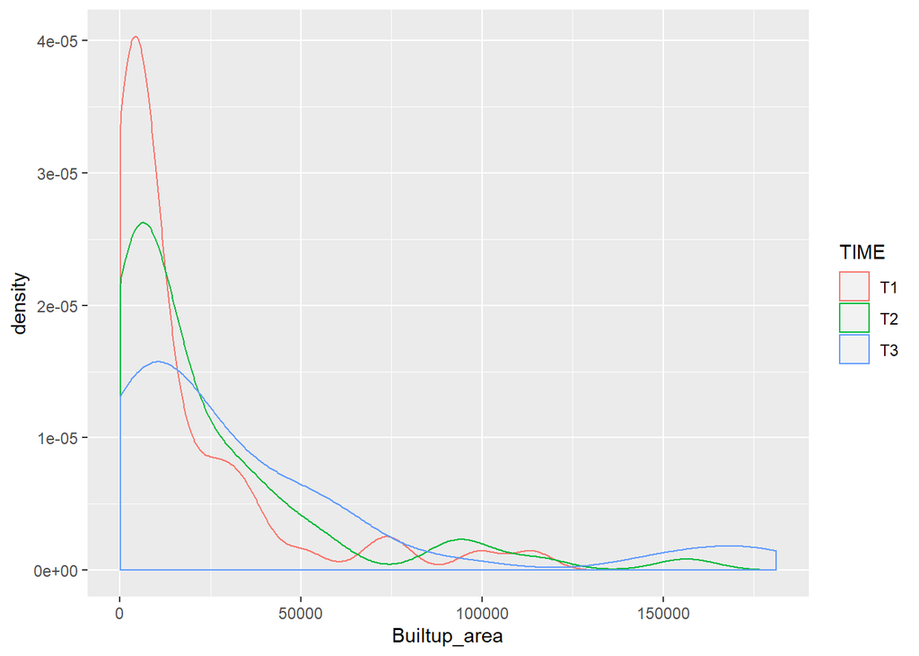

#### Diferences in the reference year IPUMS x AUE

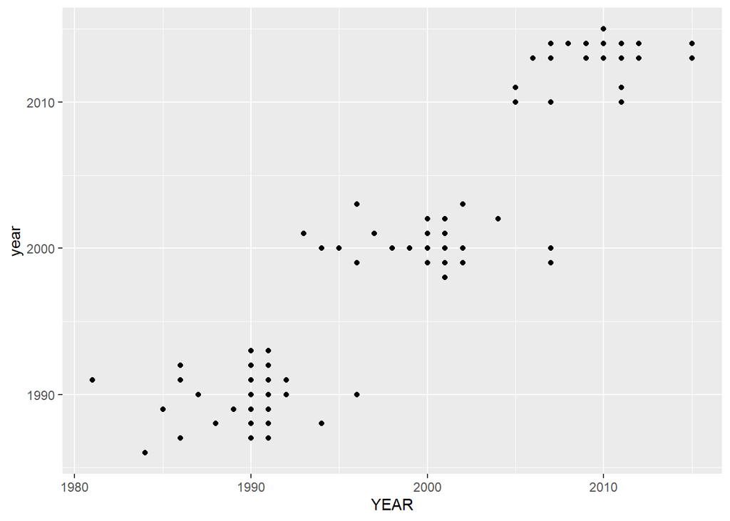

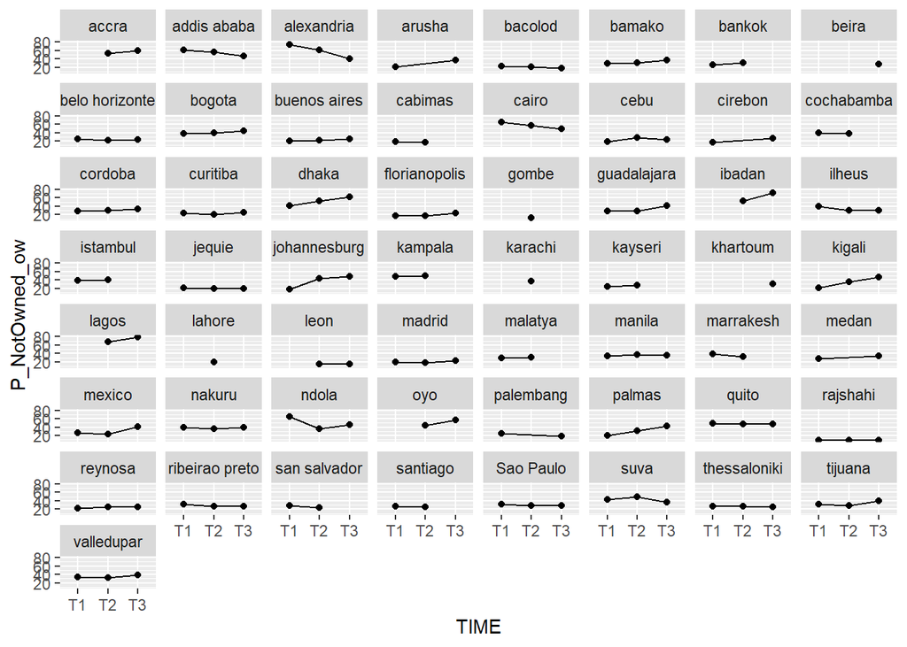